# Mod1d_lm

runlevel0

October 25, 2015

Before starting, there is a nice dataset here: http://www.ats.ucla.edu/stat/data/hsb2.csv

Thus:

### calculating slope and the linear equation in R

To find the slop (intercept) and the values of the equation I use the lm() funtction like this:

- Given two points A= (8,10) and B=(12,16) (the way they are displayed in textbooks)

```r
# x <- c(A[1],B[1]) and y <- c(A[2],B[2])

x <- c(8,12)
y <- c(10,16)

lm(y ~ x)
```

```
##
## Call:
## lm(formula = y ~ x)
##
## Coefficients:
## (Intercept)            x
##        -2.0          1.5
```

### Ploting series of coordinate pairs

*** There seems to have ben a change here as in the past it ws possible to just plot like that (not R ode as it would fail):

```
 plot(list(c(1,2),c(3,5),c(4,1)))
```

Now this fails miserably and you need to specify the values for X and Y this way:

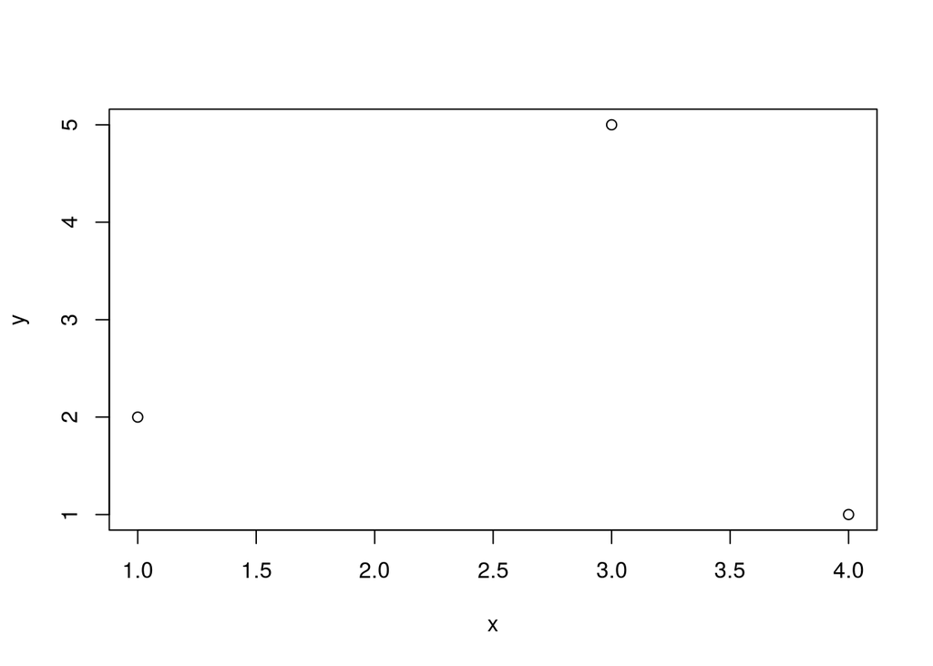

```r
#given the ordered pairs (1,2), (3,5) and (4,1)

x <- c(1,3,4)
y <- c(2,5,1)

plot(x,y)
```

*** For short tutorial see the SENIC howto (in html for convenience) ***

### Predicted value

The symbol for the predicted values for y is y-hat:

$\hat{y}=a+bx$

being *a* (or $b_0$ for multiple regression models) the intercept (-intecept) and *b* the slope coefficient

#### Y Intercept:

$a=\bar{y}-b*\bar{x}$

#### Slope Coefficient

$b=r\left(\frac{S_y}{S_x}\right)$

r * ratio of the SD of the Y values by the SD of the x values

### Outliers

Outliers can be deined / detected or eliminated calculatin the quantiles. A handy function come in:

```r
remove_outliers <- function(x, na.rm = TRUE, ...) {
  qnt <- quantile(x, probs=c(.25, .75), na.rm = na.rm, ...)
  H <- 1.5 * IQR(x, na.rm = na.rm)
  y <- x
  y[x < (qnt[1] - H)] <- NA
  y[x > (qnt[2] + H)] <- NA
  y
}
```